# ZetaSuite: A Comprehensive Guide to Multi-dimensional High-throughput Data Analysis

Yajing Hao, Shuyang Zhang, Junhui Li, Changwei Shao, Guofeng Zhao, Xiang-Dong Fu

2025-08-11

# Introduction

## Overview

ZetaSuite is an R package designed for analyzing multi-dimensional high-throughput screening data, particularly two-dimensional RNAi screens and single-cell RNA sequencing data. The package addresses the limitations of simple Z-based statistics when dealing with complex multi-dimensional datasets where experimental noise and off-target effects accumulate.

## Key Features

- **Quality Control Analysis**: Comprehensive evaluation of experimental design and data quality
- **Z-score Normalization**: Standardization using negative controls as reference
- **Event Coverage Analysis**: Quantification of regulatory effects across thresholds
- **Zeta Score Calculation**: Area-under-curve based scoring for regulatory effects
- **SVM-based Background Correction**: Machine learning approach to filter noise
- **Screen Strength Analysis**: Optimal threshold selection for hit identification
- **Single Cell Quality Control**: Cell quality assessment for scRNA-seq data

## Applications

1. **Two-dimensional RNAi screens**: Identify genes critical for cell fitness and proliferation
2. **Alternative splicing analysis**: Detect splicing regulators and their effects
3. **Single-cell RNA-seq QC**: Differentiate high-quality cells from damaged ones
4. **Cancer dependency screens**: Reveal genes with opposite roles in cancer biology

# Installation and Setup

## R Package Installation

```r
# Install from CRAN
install.packages("ZetaSuite")

# Load the package
library(ZetaSuite)
```

## Interactive Shiny Application

ZetaSuite includes an interactive web interface for easy-to-use analysis:

```r
# Launch the Shiny app
ZetaSuiteApp()

# Launch without opening browser automatically
ZetaSuiteApp(launch.browser = FALSE)

# Launch on a specific port
ZetaSuiteApp(port = 3838)
```

The Shiny app provides: - **Interactive data upload** and visualization - **Step-by-step analysis workflow** with progress indicators - **Real-time results** and interactive plots - **Data export capabilities** for all analysis results - **Built-in example dataset** for demonstration - **Bug report integration** with GitHub issues

# Example Dataset

The package includes an example dataset from an in-house HTS2 screening experiment. This dataset contains:

```r
library(ZetaSuite)

# Load example data
data(countMat)
data(negGene)
data(posGene)
data(nonExpGene)
data(ZseqList)
data(SVMcurve)

# Display data dimensions
cat("Count matrix dimensions:", dim(countMat), "\n")
```

```
## Count matrix dimensions: 1609 100
```

```r
cat("Negative controls:", nrow(negGene), "genes\n")
```

```
## Negative controls: 510 genes
```

```r
cat("Positive controls:", nrow(posGene), "genes\n")
```

```
## Positive controls: 299 genes
```

```r
cat("Non-expressed genes:", nrow(nonExpGene), "genes\n")
```

```
## Non-expressed genes: 722 genes
```

# Analysis Workflow

## Step 1: Quality Control Analysis

Quality control evaluates the ability of functional readouts to discriminate between negative and positive controls. This step provides diagnostic plots and SSMD (Strictly Standardized Mean Difference) scores.

```r
# Perform quality control analysis
qc_results <- QC(countMat, negGene, posGene)
```

[output not shown]

[output cut: 153 more lines]

[output not shown]

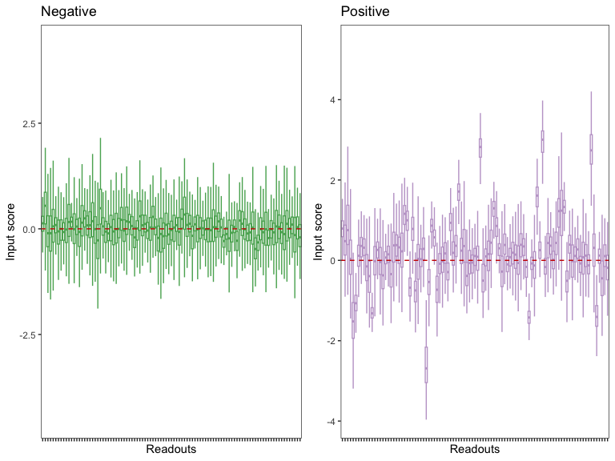

```r
# Display QC plots
cat("QC analysis completed. Generated", length(qc_results), "diagnostic plots.\n")
```

```
## QC analysis completed. Generated 4 diagnostic plots.
```

### QC Plot 1: Score Distribution

This plot shows the distribution of raw scores across all readouts for positive and negative controls.

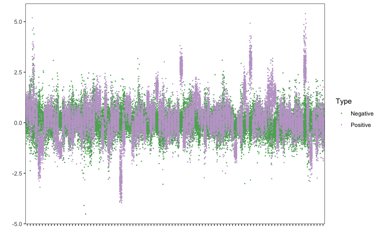

```r
qc_results$score_qc
```

### QC Plot 2: t-SNE Visualization

Global evaluation of sample separation based on all readouts.

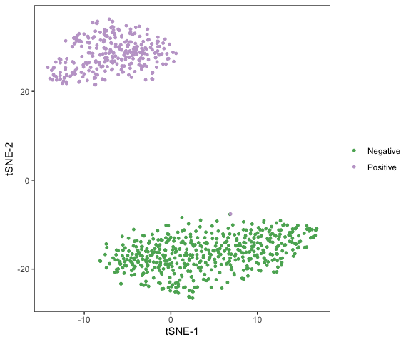

```r
qc_results$tSNE_QC
```

### QC Plot 3: Box Plots

Side-by-side comparison of score distributions between control groups.

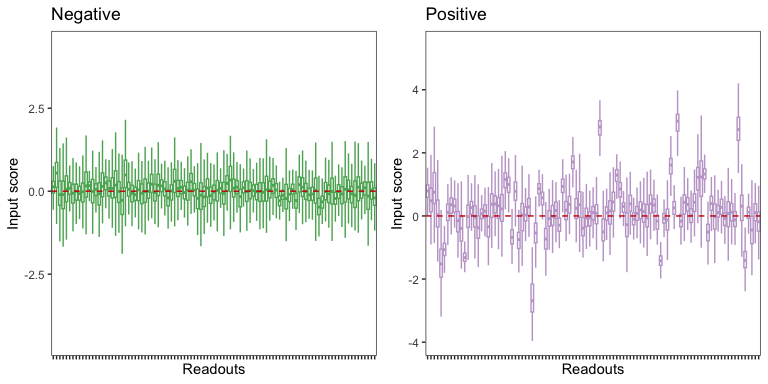

```r
grid::grid.draw(qc_results$QC_box)
```

### QC Plot 4: SSMD Distribution

Distribution of SSMD scores with quality threshold (SSMD ≥ 2).

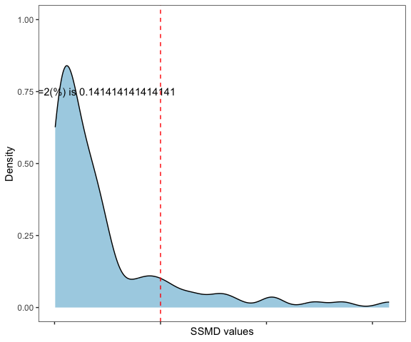

```r
qc_results$QC_SSMD
```

## Step 2: Z-score Normalization

Z-score normalization standardizes the data using negative controls as reference, making readouts comparable across different conditions.

```r
# Calculate Z-scores
zscore_matrix <- Zscore(countMat, negGene)

# Display first few rows and columns
cat("Z-score matrix dimensions:", dim(zscore_matrix), "\n")
```

```
## Z-score matrix dimensions: 1609 100
```

```r
cat("First 5 rows and columns:\n")
```

```
## First 5 rows and columns:
```

```r
print(zscore_matrix[1:5, 1:5])
```

```
##           X5621.1     X157.1     X2451.1    X6798.1     X2570.1
## HLA-DOB -2.498000  1.8430201  0.20901748  0.7276768  1.80779786
## DOK2     1.665303 -2.3679279  0.45552333  2.6441584  1.49359264
## POU3F1   0.126659 -1.1401584  0.09130339 -0.8482665 -0.32759624
## VWC2     1.170266  0.3294906 -0.74381915 -0.7616473  1.52798191
## FGFBP3   2.042632 -1.7006933 -1.53998400 -0.7430438  0.06798774
```

## Step 3: Event Coverage Analysis

Event coverage quantifies the proportion of readouts that exceed different Z-score thresholds for each gene, creating the foundation for zeta score calculations.

```r
# Calculate event coverage
ec_results <- EventCoverage(zscore_matrix, negGene, posGene, binNum = 100, combine = TRUE)

# Display event coverage plots
cat("Event coverage analysis completed.\n")
```

```
## Event coverage analysis completed.
```

### Event Coverage Plots

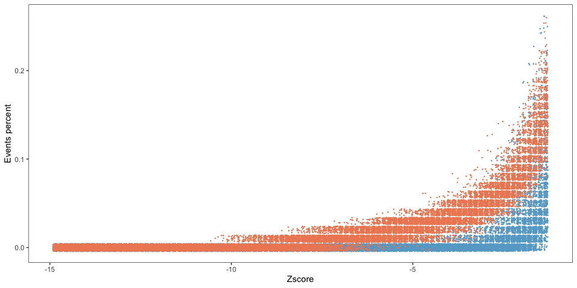

```r
# Decrease direction (exon skipping)
ec_results[[2]]$EC_jitter_D
```

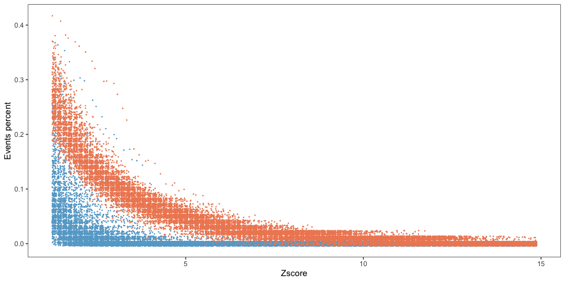

```r
# Increase direction (exon inclusion)
ec_results[[2]]$EC_jitter_I
```

## Step 4: Zeta Score Calculation

Zeta scores represent the area under the event coverage curve, quantifying the cumulative regulatory effect of each gene across all Z-score thresholds.

```r
# Calculate zeta scores without SVM correction
zeta_scores <- Zeta(zscore_matrix, ZseqList, SVM = FALSE)

# Display summary statistics
cat("Zeta score summary:\n")
```

```
## Zeta score summary:
```

```r
cat("Number of genes:", nrow(zeta_scores), "\n")
```

```
## Number of genes: 1609
```

```r
cat("Zeta_D range:", range(zeta_scores$Zeta_D), "\n")
```

```
## Zeta_D range: 0 2.508444
```

```r
cat("Zeta_I range:", range(zeta_scores$Zeta_I), "\n")
```

```
## Zeta_I range: 0.3968725 7.805159
```

```r
# Show top hits
cat("\nTop 10 genes by Zeta_D (decrease direction):\n")
```

```
##
## Top 10 genes by Zeta_D (decrease direction):
```

```r
top_decrease <- head(zeta_scores[order(zeta_scores$Zeta_D, decreasing = TRUE), ], 10)
print(top_decrease)
```

```
##          Zeta_D   Zeta_I
## IL11RA 2.508444 4.156137
## HNRNPK 2.363447 2.711962
## SRSF3  1.739961 7.805159
## 59J23  1.312221 3.726192
## 30K23  1.246972 3.163956
## 61J23  1.181724 3.836434
## 61N23  1.174474 3.582877
## 59L23  1.167224 3.770289
## 55I23  1.167224 3.208053
## 58B23  1.167224 4.409694
```

## Step 5: SVM Background Correction (Optional)

SVM analysis creates decision boundaries to separate positive and negative controls, enabling background correction in zeta score calculations.

```r
# Run SVM analysis (can be computationally intensive)
svm_results <- SVM(ec_results)

# Calculate zeta scores with SVM correction
zeta_scores_svm <- Zeta(zscore_matrix, ZseqList, SVMcurve = svm_results, SVM = TRUE)
```

## Step 6: Screen Strength Analysis

Screen Strength analysis determines optimal cutoff thresholds by balancing sensitivity and specificity, using the ratio of apparent FDR to baseline FDR.

```r
# Calculate FDR cutoffs and Screen Strength
fdr_results <- FDRcutoff(zeta_scores, negGene, posGene, nonExpGene, combine = TRUE)
```

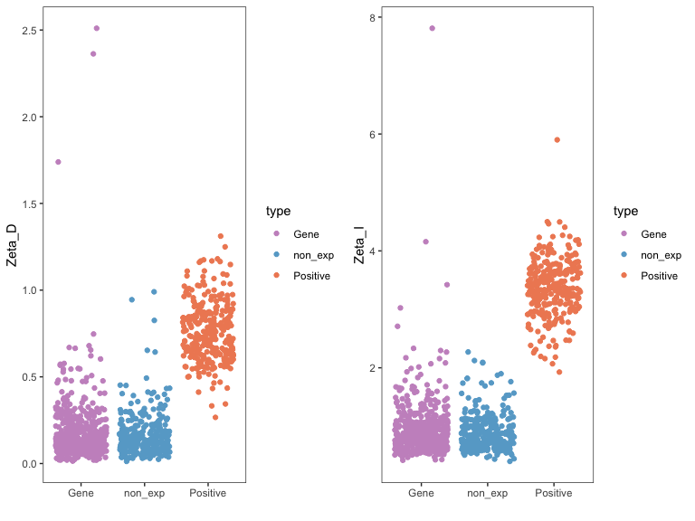

```r
# Display Screen Strength plots
cat("Screen Strength analysis completed.\n")
```

```
## Screen Strength analysis completed.
```

### Zeta Score Distribution by Gene Type

```r
fdr_results[[2]]$Zeta_type
```

### Screen Strength Curves

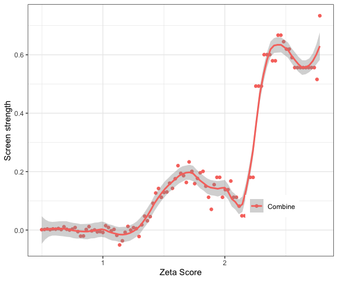

```r
fdr_results[[2]]$SS_cutOff
```

### FDR Cutoff Results

```r
# Display FDR cutoff results
fdr_table <- fdr_results[[1]]
cat("FDR cutoff results summary:\n")
```

```
## FDR cutoff results summary:
```

```r
cat("Number of thresholds tested:", nrow(fdr_table), "\n")
```

```
## Number of thresholds tested: 101
```

```r
cat("Screen Strength range:", range(fdr_table$SS), "\n")
```

```
## Screen Strength range: -0.05104725 0.7336667
```

```r
# Show optimal thresholds (SS > 0.8)
optimal_thresholds <- fdr_table[fdr_table$SS > 0.8, ]
cat("\nOptimal thresholds (SS > 0.8):\n")
```

```
##
## Optimal thresholds (SS > 0.8):
```

```r
print(head(optimal_thresholds, 10))
```

```
## [1] Cut_Off    aFDR       SS         TotalHits  Num_nonExp Type
## <0 rows> (or 0-length row.names)
```

## Step 7: Hit Selection

Based on the Screen Strength analysis, select appropriate thresholds for hit identification.

```r
# Example: Select threshold with SS > 0.8 and reasonable number of hits
selected_threshold <- fdr_table[fdr_table$SS > 0.8 & fdr_table$TotalHits > 50, ]
if(nrow(selected_threshold) > 0) {
  best_threshold <- selected_threshold[which.max(selected_threshold$SS), ]
  cat("Recommended threshold:", best_threshold$Cut_Off, "\n")
  cat("Screen Strength:", best_threshold$SS, "\n")
  cat("Total hits:", best_threshold$TotalHits, "\n")

  # Identify hits
  combined_zeta <- zeta_scores$Zeta_D + zeta_scores$Zeta_I
  hits <- names(combined_zeta[combined_zeta >= best_threshold$Cut_Off])
  cat("Number of hits identified:", length(hits), "\n")
}
```

# Single Cell RNA-seq Quality Control

ZetaSuite also provides functionality for single-cell RNA-seq quality control, helping to differentiate high-quality cells from damaged ones.

```r
# Example single cell analysis (requires single cell count matrix)
# single_cell_results <- ZetaSuitSC(count_matrix_sc, binNum = 10, filter = TRUE)
```

# Advanced Usage

## Custom Parameter Settings

```r
# Custom event coverage analysis
ec_custom <- EventCoverage(zscore_matrix, negGene, posGene,
                          binNum = 200,    # More bins for finer resolution
                          combine = FALSE) # Separate decrease/increase directions

# Custom zeta score calculation with SVM
zeta_custom <- Zeta(zscore_matrix, ZseqList,
                   SVMcurve = svm_results,
                   SVM = TRUE)  # Use SVM correction

# Custom FDR analysis
fdr_custom <- FDRcutoff(zeta_scores, negGene, posGene, nonExpGene,
                       combine = FALSE)  # Analyze directions separately
```

## Batch Processing

```r
# Example: Process multiple datasets
datasets <- list(dataset1 = list(countMat = countMat1, negGene = negGene1),
                dataset2 = list(countMat = countMat2, negGene = negGene2))

results <- lapply(datasets, function(ds) {
  zscore <- Zscore(ds$countMat, ds$negGene)
  ec <- EventCoverage(zscore, ds$negGene, ds$posGene, binNum = 100)
  zeta <- Zeta(zscore, ZseqList, SVM = FALSE)
  return(list(zscore = zscore, ec = ec, zeta = zeta))
})
```

# Interpretation Guidelines

## Quality Control Interpretation

- **SSMD ≥ 2**: High-quality readouts with good separation between controls
- **t-SNE separation**: Clear clustering indicates good experimental design
- **Box plot overlap**: Minimal overlap suggests effective control design

## Zeta Score Interpretation

- **Higher Zeta_D**: Genes promoting exon skipping
- **Higher Zeta_I**: Genes promoting exon inclusion
- **Combined score**: Overall regulatory effect strength

## Screen Strength Interpretation

- **SS = 1**: Perfect separation (no false positives)
- **SS > 0.8**: Excellent separation
- **SS > 0.6**: Good separation
- **Optimal threshold**: Balance between sensitivity and specificity

# Troubleshooting

## Common Issues

1. **Insufficient controls**: Ensure adequate number of positive/negative controls
2. **Data quality**: Check for missing values and extreme outliers
3. **Memory issues**: Reduce bin number for large datasets
4. **SVM convergence**: Adjust SVM parameters or use pre-calculated curves

## Performance Optimization

- Use `combine = TRUE` for faster event coverage analysis
- Reduce `binNum` for large datasets
- Consider using pre-calculated SVM curves for repeated analyses

# References

## Software Citation

Hao, Y., Shao, C., Zhao, G., Fu, X.D. (2021). ZetaSuite: A Computational Method for Analyzing Multi-dimensional High-throughput Data, Reveals Genes with Opposite Roles in Cancer Dependency. *Forthcoming*

## Dataset Citation

Shao, C., Hao, Y., Qiu, J., Zhou, B., Li, H., Zhou, Y., Meng, F., Jiang, L., Gou, L.T., Xu, J., Li, Y., Wang, H., Yeo, G.W., Wang, D., Ji, X., Glass, C.K., Aza-Blanc, P., Fu, X.D. (2021). HTS2 Screen for Global Splicing Regulators Reveals a Key Role of the Pol II Subunit RPB9 in Coupling between Transcription and Pre-mRNA Splicing. *Cell. Forthcoming*